# Chulwalar Case Study

#### Based on the above plots we observe the following -

#### The STL decompose the BlueEtelAsIs data into 4 plots - the Observed, Seasonal, Trend and Random

#### From the Trend plot we can see a -ve trend in the export of Blue Etel from 2008 to 2011, and the trend becomes positive from 2011 thru 2013

#### From the seasonal plot we can see that the exports fall during summer and then after the exquinox around Sept the exports pick up and we see a small reduction in exports during december which coincides with the indpendence day celebrations and again rises till march equinox

#### 3 - Correlation with indicators

#### The following indicators are to be tested:

#### 1 Monthly Change in Export Price Index (CEPI)

#### 2 Monthly Satisfaction Index (SI) government based data

#### 3 Average monthly temperatures in Chulwalar

#### 4 Monthly births in Chulwalar

#### 5 Monthly Satisfaction Index (SI) external index

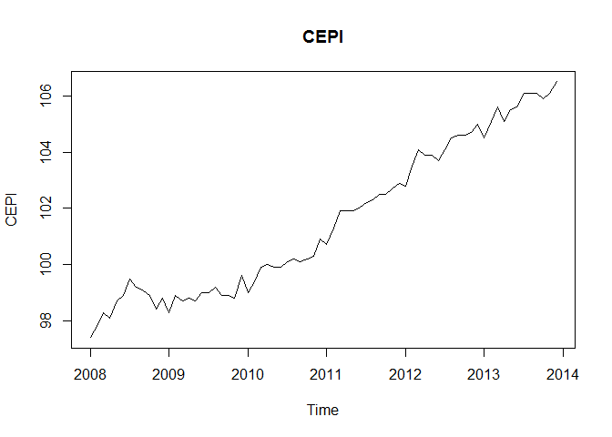

```r
CEPIVector <- c(ImportedIndicators[2:13,2],ImportedIndicators[2:13,3],ImportedIndicators[2:13,4],ImportedIndicators[2:13,5],ImportedIndicators[2:13,6],ImportedIndicators[2:13,7])
CEPI <- ts(CEPIVector , start=c(2008,1), end=c(2013,12), frequency=12)
plot(CEPI, main="CEPI")
```

```r
cor(BlueEtelAsIs , CEPI)
```

```
## [1] 0.1448837
```

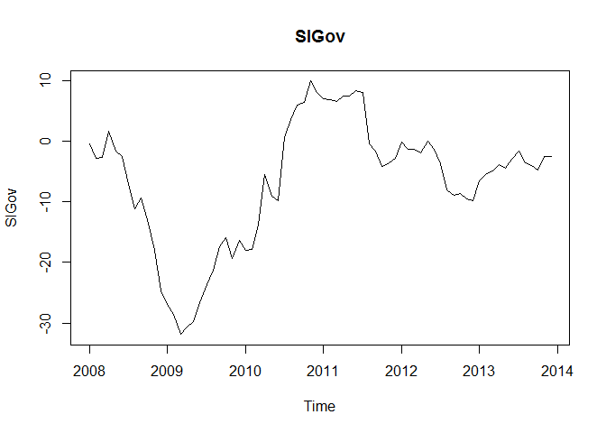

```r
SIGovVector <- c(ImportedIndicators[16:27,2],ImportedIndicators[16:27,3],ImportedIndicators[16:27,4],ImportedIndicators[16:27,5],ImportedIndicators[16:27,6],ImportedIndicators[16:27,7])
SIGov <- ts(SIGovVector , start=c(2008,1), end=c(2013,12), frequency=12)
plot(SIGov, main="SIGov")
```

```r
cor(BlueEtelAsIs , SIGov)
```

```
## [1] -0.04146932
```

```r
TemperatureVector <- c(ImportedIndicators[30:41,2],ImportedIndicators[30:41,3],ImportedIndicators[30:41,4],ImportedIndicators[30:41,5],ImportedIndicators[30:41,6],ImportedIndicators[30:41,7])
Temperature <- ts(TemperatureVector, start=c(2008,1), end=c(2013,12), frequency=12)

cor(BlueEtelAsIs , Temperature)
```

```
## [1] -0.6356067
```

```r
BirthsVector <- c(ImportedIndicators[44:55,2],ImportedIndicators[44:55,3],ImportedIndicators[44:55,4],ImportedIndicators[44:55,5],ImportedIndicators[44:55,6],ImportedIndicators[44:55,7])
Births <- ts(BirthsVector, start=c(2008,1), end=c(2013,12), frequency=12)

cor(BlueEtelAsIs , Births)
```

```
## [1] -0.2812913
```

#### Based on the above correlations we can see that the temperature has a strong correlation to the BlueEtelAsIs